# data_analysis.Rmd

Ross Cunning, Hollie Putnam, Danielle Claar

1/23/2018

## Load packages and set options

# Analyze temperature regimes at each site

## Supplementary Figure 1

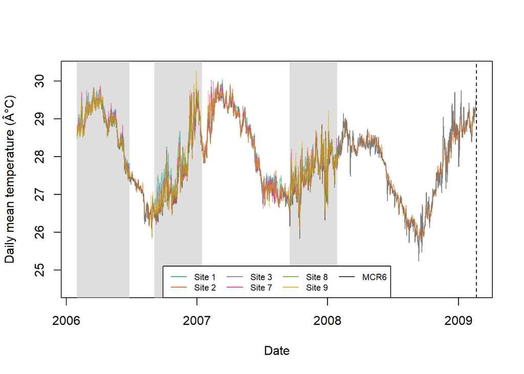

```r
# Load temperature data
load("Data/tempdata.RData") # loads the temperature data from temperature_analysis

#########################
# Plot temperature supplemental figure
library(zoo)
sitecolors <- c('#1b9e77','#d95f02','#7570b3','#e7298a','#66a61e','#e6ab02')
# Plot daily rolling means for the whole time interval (MCR6)

plot(rollapply(MCR.6$Temp, 24, FUN=mean, fill=NA) ~ MCR.6$Date.Time, col="white",
     xlim=c(as.POSIXct("2006-01-31"), as.POSIXct("2009-02-20")),
     ylim=c(24.5, 30.3),
     xlab="Date", ylab="Daily mean temperature (Â°C)")
dates <- unique(as.Date(temp.all$Date.Time))
breaks <- sort(c(1, which(diff(dates)!=1), which(diff(dates)!=1)+1, length(dates)))
for (i in c(1,3,5)) {
  ss <- dates[breaks[i]:breaks[i+1]]
  rect(as.POSIXct(first(ss)), 24, as.POSIXct(last(ss)), 32, col=alpha("gray", 0.5), border=NA)
}
# Add lines for each site
with(MCR.6, lines(rollapply(Temp, 24, FUN=mean, fill=NA) ~ Date.Time, type="l", col=alpha("black", 0.5)))
with(Site.1, lines(rollapply(Site.1, 24, FUN=mean, fill=NA) ~ Date.Time, type="l", col=alpha(sitecolors[1], 0.5)))
with(Site.2, lines(rollapply(Site.2, 24, FUN=mean, fill=NA) ~ Date.Time, type="l", col=alpha(sitecolors[2], 0.5)))
with(Site.3, lines(rollapply(Site.3, 24, FUN=mean, fill=NA) ~ Date.Time, type="l", col=alpha(sitecolors[3], 0.5)))
with(Site.7, lines(rollapply(Site.7, 24, FUN=mean, fill=NA) ~ Date.Time, type="l", col=alpha(sitecolors[4], 0.5)))
with(Site.8, lines(rollapply(Site.8, 24, FUN=mean, fill=NA) ~ Date.Time, type="l", col=alpha(sitecolors[5], 0.5)))
with(Site.9, lines(rollapply(Site.9, 24, FUN=mean, fill=NA) ~ Date.Time, type="l", col=alpha(sitecolors[6], 0.5)))

# Add line indicating sampling timepoint
abline(v=as.POSIXct("2009-02-20"), lty=2)

# Add legend
legend("bottom", lty=1, legend=c("Site 1", "Site 2", "Site 3", "Site 7", "Site 8", "Site 9", "MCR6"),
       col=c(sitecolors, "black"), ncol=4, cex=0.7)
```

```r
#################
```

## Temperature data summary

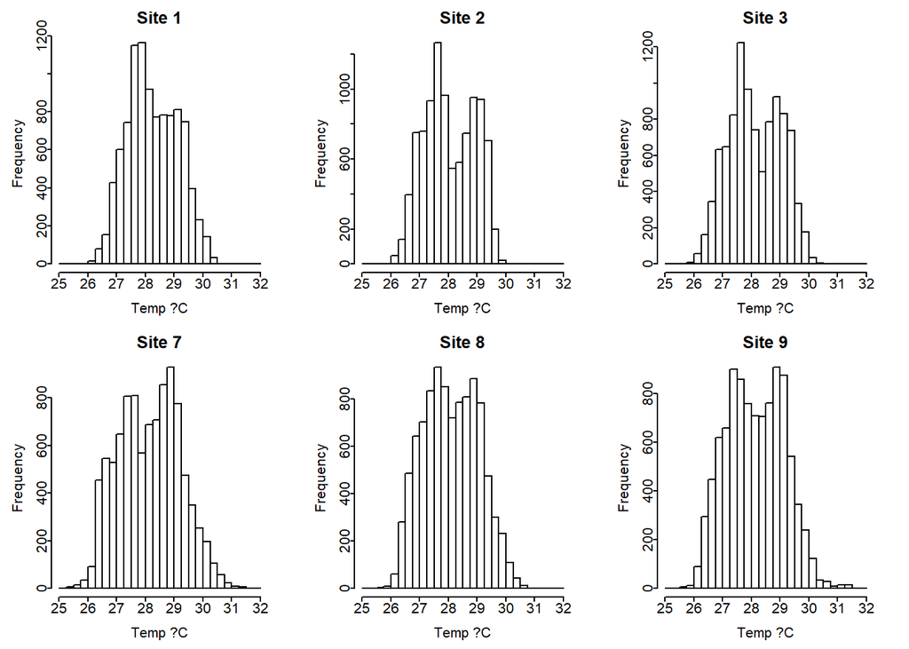

```r
sitecolors <- c("#762a83", "#9970ab", "#c2a5cf", "#a6dba0", "#5aae61", "#1b7837")
# Plot temperature distributions for each site
par(mfrow=c(2,3), mar=c(3,3,2,2), mgp=c(1.5,0.1,0), tcl=-0.2)
hist(temp.all$Site.1, xlim=c(25,32), breaks=seq(25,32,0.25),
     main="Site 1", xlab="Temp ?C")
hist(temp.all$Site.2, xlim=c(25,32), breaks=seq(25,32,0.25),
     main="Site 2", xlab="Temp ?C")
hist(temp.all$Site.3, xlim=c(25,32), breaks=seq(25,32,0.25),
     main="Site 3", xlab="Temp ?C")
hist(temp.all$Site.7, xlim=c(25,32), breaks=seq(25,32,0.25),
     main="Site 7", xlab="Temp ?C")
hist(temp.all$Site.8, xlim=c(25,32), breaks=seq(25,32,0.25),
     main="Site 8", xlab="Temp ?C")
hist(temp.all$Site.9, xlim=c(25,32), breaks=seq(25,32,0.25),
     main="Site 9", xlab="Temp ?C")
```

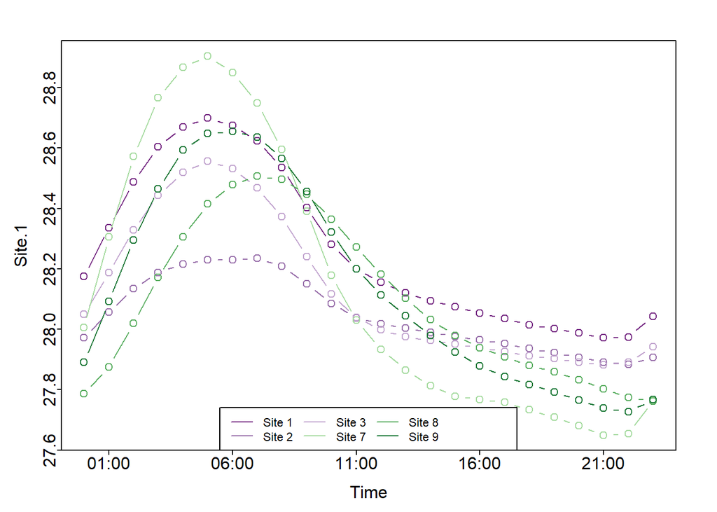

```r
# Plot mean daily cycle for each site
times <- strptime(temp.all$Date.Time, format="%Y-%m-%d %H:%M:%S")
temp.all$Time <- format(as.POSIXct(times), format="%H:%M")
time.mean<-aggregate(cbind(temp.all$Site.1,temp.all$Site.2,temp.all$Site.3,temp.all$Site.7,temp.all$Site.8,temp.all$Site.9) ~ temp.all$Time, FUN=mean)
colnames(time.mean) <- c("Time","Site.1","Site.2","Site.3","Site.7","Site.8","Site.9")
time.mean$Time <- as.POSIXct(time.mean$Time, format="%H:%M")
par(mfrow=c(1,1), mar=c(3,3,2,2), mgp=c(1.5,0.1,0), tcl=-0.2)
with(time.mean, {
  plot(Time, Site.1, type="b", ylim=range(time.mean[,2:7]), col=sitecolors[1])
  points(Time, Site.2, type="b", col=sitecolors[2])
  points(Time, Site.3, type="b", col=sitecolors[3])
  points(Time, Site.7, type="b", col=sitecolors[4])
  points(Time, Site.8, type="b", col=sitecolors[5])
  points(Time, Site.9, type="b", col=sitecolors[6])
})
legend("bottom", lty=1, legend=c("Site 1", "Site 2", "Site 3", "Site 7", "Site 8", "Site 9"),
       col=sitecolors, ncol=4, cex=0.7)
```

```r
# View Descriptive Stats
temp.summ
```

```
##            mean       var      min      max       skew         dip
## Site.1 28.25910 0.7521661 26.19450 30.61683 0.12347271 0.004580796
## Site.2 28.04555 0.7589079 25.99000 30.13333 0.03403015 0.021484390
## Site.3 28.12609 0.8249492 25.93483 30.34333 0.01894512 0.017851064
## Site.7 28.13881 1.1379003 25.31325 31.42467 0.08394553 0.010585890
## Site.8 28.09150 0.9075635 25.68900 30.77317 0.08682948 0.008921383
## Site.9 28.13406 0.9943545 25.58000 31.49283 0.10615232 0.012986861
##        daily.mean.min daily.mean.max daily.mean.range daily.mean.var
## Site.1       27.90236       28.77776        0.8754021     0.09928326
## Site.2       27.82022       28.33237        0.5121503     0.03272741
## Site.3       27.79952       28.64005        0.8405388     0.09501431
## Site.7       27.52083       29.08137        1.5605382     0.34039821
## Site.8       27.68489       28.63906        0.9541657     0.14372390
## Site.9       27.63384       28.81665        1.1828082     0.21029082
##        daysover30 daysover31 daysunder27 daysunder27.5 daysunder28
## Site.1         40          0           3            11          66
## Site.2          2          0          16            64         189
## Site.3         15          0           2            16          99
## Site.7         91          6           4            29          67
## Site.8         38          0          12            55         126
## Site.9         46          6           6            34          89
```

## Multivariate temperature analysis

### Principal component analysis

```r
## Set which temperature metrics to include in PCA
include <- c("var", "daily.mean.range", "daysover30")
#include <- c("mean", "var", "daily.mean.min", "daily.mean.max", "daily.mean.range",
#             "daysover30", "daysunder27")

## Subset temperature metrics for PCA
temp <- as.data.frame(temp.summ[, include])

## Run PCA
pca.temp <- prcomp(temp, scale=TRUE)
par(mfrow=c(1,1))
#screeplot(pca.temp)

## Calculate loading values of original metrics
aload <- abs(pca.temp$rotation)
sweep(aload, 2, colSums(aload), "/")
```

```
##                        PC1        PC2       PC3
## var              0.3284108 0.50320556 0.2004742
## daily.mean.range 0.3400424 0.06445106 0.4927388
## daysover30       0.3315468 0.43234338 0.3067869
```

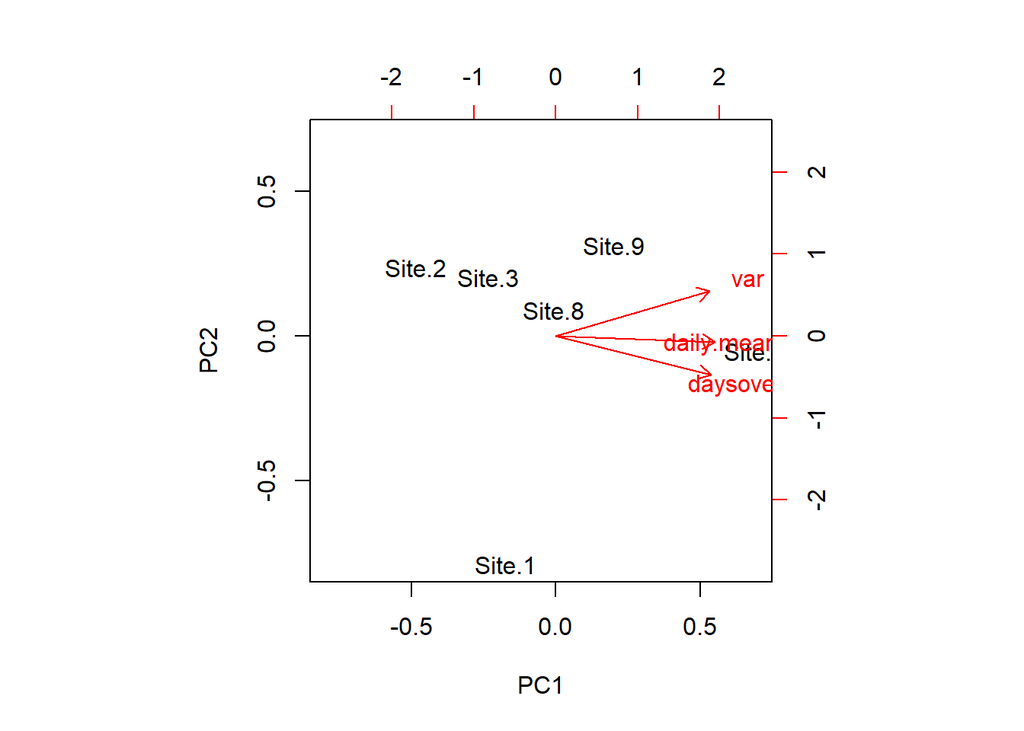

```r
## Extract temperature PC values for each site
temp.PCs <- pca.temp$x

## Visualize PCA as biplot
biplot(pca.temp)
```

```r
summary(pca.temp)
```

```
## Importance of components:
##                           PC1     PC2    PC3
## Standard deviation     1.6856 0.37155 0.1439
## Proportion of Variance 0.9471 0.04602 0.0069
## Cumulative Proportion  0.9471 0.99310 1.0000
```

### Temperature regime radar chart

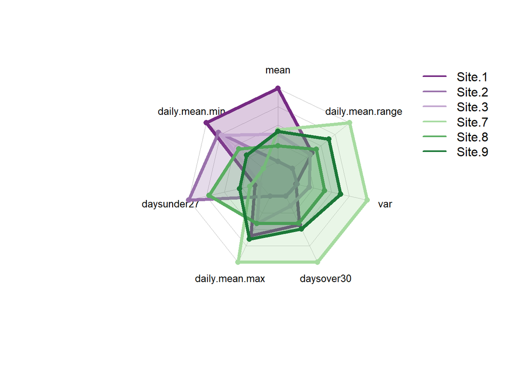

```r
# Calculate ranges of each column
temp2 <- rbind(apply(as.data.frame(temp.summ), 2, function(x) rev(range(x))),
               as.data.frame(temp.summ))
# Reorder columns
temp2 <- temp2[, c(1,7,13,8,11,2,9)]
# Plot radar chart
rad <- radarchart(
  temp2,

  #custom polygon
  plwd=4, plty=1,

  #custom colors
  pcol=sitecolors,
  pfcol=scales::alpha(sitecolors, 0.25),

  #custom the grid
  cglcol="grey", cglty=1, axislabcol="grey", cglwd=0.8,

  #custom labels
  vlcex=0.8
)

legend("topright", rownames(temp2)[-(1:2)], lty=1, lwd=2, col=sitecolors, bty="n")
```

# Figure 1

```r
tiff("Output/Fig1.tiff", width=10, height=3, units="in", res=300)
par(mfrow=c(1,2), mgp=c(1,0.1,0), tcl=0.25, cex.lab=1, cex.axis=0.8,
    mar=c(2,2,2,2))
layout(matrix(c(1,2,3), nrow=1, ncol=3, byrow = TRUE), heights=c(1,0.8,0.75), widths=c(3.5,3,3.5))

# Panel A
#### MAP OF MOOREA SHOWING SITE LOCATIONS
moorea <- load.image('Output/Moorea_temp_logger_map.png')
plot(moorea, axes=F, rescale=FALSE)
title("a", adj=0)

# Panel B
#biplot(pca.temp, cex=0.9, bty="n", xpd=NA, expand=1.1,
#       ylabs=c("Dip","Daily Mean\nMinimum   ","Mean","Days\nOver 30?C","Variance","Daily Mean  #  \nMaximum   ","Days Under\n27?C"),
#       xlim=c(-0.85,0.75),
#       ylim=c(-0.75,0.75))
#title("b", adj=0)

# Panel B
par(mar=c(1.5,1,1.5,2), xpd=NA)
rad <- radarchart(
  temp2,

  #custom polygon
  plwd=2, plty=1,

  #custom colors
  pcol=sitecolors,
  pfcol=scales::alpha(sitecolors, 0.25),

  #custom the grid
  cglcol="grey", cglty=1, axislabcol="grey", cglwd=0.8,

  #custom labels
  vlcex=1,
  vlabels = c("Mean", "Mean Daily\nMin.", "Days\nunder 27Â°C", "Mean Daily\nMax.",
              "Days over 30Â°C", "Variance", "Mean Daily\nRange")
)
title("b", adj=0.05, line = 0)
legend("topright", legend=c("Site 1", "Site 2", "Site 3", "Site 7", "Site 8", "Site 9"),
       lty=1, lwd=2, col=sitecolors, bty="n", cex=0.9, ncol=2, inset=c(-0.02,-0.05))
dev.off()
```

# Analyze *Symbiodinium* communities

## Load *Symbiodinium* data

```r
# Load Symbiodinium data from saved phyloseq objects
#load("Data/Moorea_sym100_f.RData")  # loads phyloseq object for 100% OTUs named phy.f
#phy100.f <- phy.f # renames to phy100.f
load("Data/Moorea_sym_f.RData")  # loads phyloseq object for 97%-within-sample OTUs named phy.f

# Append site temperature metrics to sample_data in phyloseq objects
site.levels <- as.numeric(sample_data(phy.f)$Site)
sample_data(phy.f)$mean <- temp.summ[site.levels, "mean"]
sample_data(phy.f)$var <- temp.summ[site.levels, "var"]
#sample_data(phy.f)$dip <- temp[site.levels, "dip"]
sample_data(phy.f)$daily.mean.min <- temp.summ[site.levels, "daily.mean.min"]
sample_data(phy.f)$daily.mean.max <- temp.summ[site.levels, "daily.mean.max"]
sample_data(phy.f)$daily.mean.range <- temp.summ[site.levels, "daily.mean.range"]
sample_data(phy.f)$daysover30 <- temp.summ[site.levels, "daysover30"]
sample_data(phy.f)$daysunder27 <- temp.summ[site.levels, "daysunder27"]

# Append site temperature PCs to sample_data in phyloseq objects
sample_data(phy.f)$PC1 <- temp.PCs[site.levels, "PC1"]
sample_data(phy.f)$PC2 <- temp.PCs[site.levels, "PC2"]
sample_data(phy.f)$PC3 <- temp.PCs[site.levels, "PC3"]
#sample_data(phy.f)$PC4 <- temp.PCs[site.levels, "PC4"]


# Convert OTU counts to proportions (relative abundances)
phy.f.p <- transform_sample_counts(phy.f, function(x) x/sum(x))
# Square-root transform relative abundances
transform <- function(x) sqrt(x/sum(x))  # Set transformation function
phy.f.t <- transform_sample_counts(phy.f, transform)  # Transform data

# Save OTU table and tax table as supplementary tables
write.csv(otu_table(phy.f.p), file="Output/OTU_table.csv", row.names=F, quote=F)
write.csv(tax_table(phy.f.p), file="Output/tax_table.csv", row.names=F, quote=F)
```

## Visualize *Symbiodinium* clade abundances

The relative abundance of each clade in the entire dataset (normalized for differences in sequencing depth across samples).

```r
cladeAbund <- aggregate(data.frame(RelAbund=rowSums(otu_table(phy.f.p))),
                        by=list(Clade=data.frame(tax_table(phy.f.p))$Clade), FUN=sum)
cladeAbund$Prop <- prop.table(cladeAbund$RelAbund)
cladeAbund[,-2]
```

```
##   Clade       Prop
## 1     A 0.14499106
## 2     C 0.80722750
## 3     D 0.04778144
```

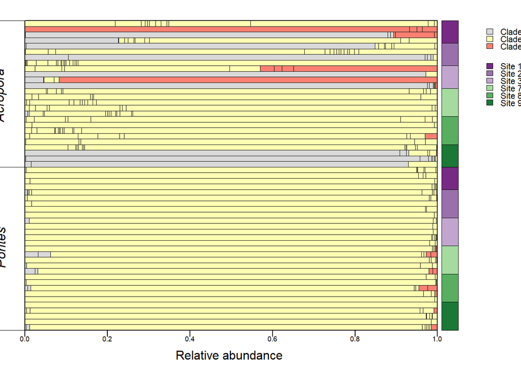

```r
composition <- function(phy, col, legend=T) {
  samdat <- data.frame(sample_data(phy))
  #samdat$Genus <- factor(samdat$Genus, levels=rev(levels(samdat$Genus)))
  samdat$Species <- factor(samdat$Species, levels=rev(levels(samdat$Species)))
  samdat$Site <- factor(samdat$Site, levels=rev(levels(samdat$Site)))
  samdat <- samdat[with(samdat, order(Species, Site, -DNA.ID)), ]
  typerelabund <- as.matrix(otu_table(phy)[order(data.frame(tax_table(phy))$hit),
                                           rownames(samdat)])
  sitebreaks <- c(as.character(samdat$Site), "X")==c("X", as.character(samdat$Site))
  sitebreaks <- which(sitebreaks==F) - 1
  spbreaks <- c(which(duplicated(samdat$Species)==F) - 1, nrow(samdat))

  # Make Barplot
  par(mar=c(4,2,2,8))
  barplot(typerelabund, horiz=T, space=0, axes=F,axisnames=F, yaxs="i", col=col)
  rect(0, 0, par("usr")[2], par("usr")[4], lwd=1, xpd=T)
  axis(side=1, at=seq(0, 1, 0.2), line=0, tck=-0.02, mgp=c(0,0.25,0), cex.axis=0.8)
  mtext(side=1, "Relative abundance", cex=1, line=2)
  # Add legend
  if (legend==T) {
    legend(x=1.1, y=par("usr")[4]*0.90, xjust=0, yjust=0.1, bty="n", xpd=T,
           cex=1, pt.cex=1, legend=c("Clade A", "Clade C", "Clade D"),
           fill=taxcolors, y.intersp=0.7)
    legend(x=1.1, y=par("usr")[4]*0.725, xjust=0, yjust=0.1, bty="n", xpd=T, cex=1,
           pt.cex=1, legend=c("Site 1", "Site 2", "Site 3", "Site 7", "Site 8", "Site 9"),
           fill=sitecolors, y.intersp=0.7)
  }
  # Add grouping bars for Site
  sitecolors <- matrix(sitecolors,
              dimnames=list(c(" Site 1", " Site 2", " Site 3",
                              " Site 7", " Site 8", " Site 9")))
  for (i in 1:(length(sitebreaks)-1)) {
    lines(c(0, 1), c(sitebreaks[i], sitebreaks[i]), lty=2, lwd=0.25)
    rect(1.01, sitebreaks[i], 1.05, sitebreaks[i+1],
         col=sitecolors[as.character(samdat$Site[sitebreaks[i]+1]),],
         lwd=0.25, xpd=T)
  }

  # Add lines to separate species and species names
  for (i in 1:length(spbreaks)) {
    lines(c(-0.08, 1), c(spbreaks[i], spbreaks[i]), xpd=T, type="l", lwd=0.6)
  }
  text(-0.07, c(11,37), xpd=T, pos=4, cex=1.5, srt=90,
         labels=c(expression(italic("Porites")),
                  expression(italic("Acropora"))))
  #for (i in 1:nrow(samdat)) {
  #  text(0, i-0.5, rownames(samdat)[i], xpd=T, cex=0.7, pos=2)
  #}
}

par(mfrow=c(1,1), mar=c(2, 1.5, 2, 10), lwd=0.1, cex=0.7, xpd=NA)
# Plot composition of 97% within-sample OTUs colored by clade
composition(phy.f.p, col=taxcolors[factor(data.frame(tax_table(phy.f.p))[order(data.frame(tax_table(phy.f.p))$Subtype), ]$Clade, levels=c("A","C","D"))], legend=T)
```

```r
tiff("Output/Fig2.tiff", width=3.5, height=5, units="in", res=300)
par(mfrow=c(1,1), mar=c(2, 1.5, 2, 10), lwd=0.1, cex=0.7, xpd=NA)
# Plot composition of 97% within-sample OTUs colored by clade
composition(phy.f.p, col=taxcolors[factor(data.frame(tax_table(phy.f.p))[order(data.frame(tax_table(phy.f.p))$Subtype), ]$Clade, levels=c("A","C","D"))], legend=T)
dev.off()
```

## Build *Symbiodinium* phylogenetic tree

```r
#https://rdrr.io/rforge/seqinr/man/dist.alignment.html
#returns sqrt of pairwise genetic distance, then squared the matrices
A.seqs <- read.alignment(file = "Data/A_tree_seqs_aligned_clean.fasta", format= "fasta")
A.dis <- (as.matrix(dist.alignment(A.seqs, matrix = "identity" )))^2

C.seqs <- read.alignment(file = "Data/C_tree_seqs_aligned_clean.fasta", format= "fasta")
C.dis <- (as.matrix(dist.alignment(C.seqs, matrix = "identity" )))^2

D.seqs <- read.alignment(file = "Data/D_tree_seqs_aligned_clean.fasta", format= "fasta")
D.dis <- (as.matrix(dist.alignment(D.seqs, matrix = "identity" )))^2

#give clade distances using average 28s distance from Pochon and Gates 2010
A_C <- matrix(0.1960, ncol=ncol(A.dis), nrow=nrow(C.dis), dimnames=list(rownames(C.dis), colnames(A.dis)))
A_D <- matrix(0.1775, ncol=ncol(A.dis), nrow=nrow(D.dis), dimnames=list(rownames(D.dis), colnames(A.dis)))
C_D <- matrix(0.1520, ncol=ncol(C.dis), nrow=nrow(D.dis), dimnames=list(rownames(D.dis), colnames(C.dis)))

#build ACD matrix
col1 <- rbind(A.dis, A_C, A_D)
col2 <- rbind(matrix(NA, nrow=nrow(A.dis), ncol=ncol(C.dis), dimnames=list(rownames(A.dis), colnames(C.dis))), C.dis, C_D)
col3 <- rbind(matrix(NA, nrow=nrow(A.dis)+nrow(C.dis), ncol=ncol(D.dis), dimnames=list(c(rownames(A.dis), rownames(C.dis)), colnames(D.dis))), D.dis)

ubermatrix <- cbind(col1, col2, col3)

#build tree
uber.tree <- phangorn::upgma(ubermatrix)

# Slot uber tree into the phy_tree slot of the phyloseq object
phy_tree(phy.f) <- phy_tree(uber.tree)
phy_tree(phy.f.p) <- phy_tree(uber.tree)
phy_tree(phy.f.t) <- phy_tree(uber.tree)
```

## Ordinate *Symbiodinium* communities

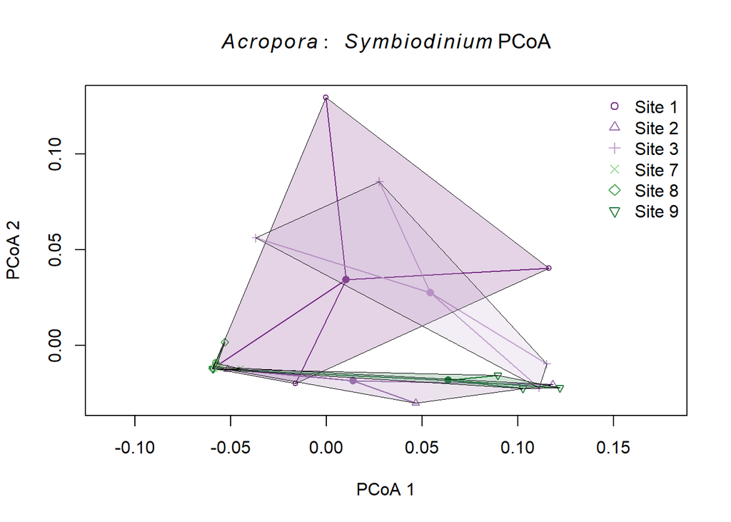

```r
par(lwd=1, cex=1)
# Separate Acropora and Porites
phy.f.t.porites <- subset_samples(phy.f.t,Species=="Porties")
phy.f.t.acropora <- subset_samples(phy.f.t,Species=="Acropora")

# Principal coordinate analysis using weighted UniFrac distances

## Acropora
acr.ufdist <- UniFrac(phy.f.t.acropora, weighted=T, normalized=F, parallel=F, fast=T)
acr.bd <- betadisper(d=acr.ufdist, group=sample_data(phy.f.t.acropora)$Site,
                       type="centroid", bias.adjust=FALSE)
plot(acr.bd, hull=F, label=F, col=sitecolors, seg.col=sitecolors,
     main=expression(italic(Acropora:~~Symbiodinium)~"PCoA"),
     xlab="PCoA 1", ylab="PCoA 2", sub="")
ordihull(acr.bd, sample_data(phy.f.t.acropora)$Site,  draw = c("polygon"),
         col = sitecolors, alpha=0.2, lwd=0.05)
legend("topright", bty="n", pch=1:6,
       legend=levels(sample_data(phy.f.t.acropora)$Site),
       col=sitecolors)
```

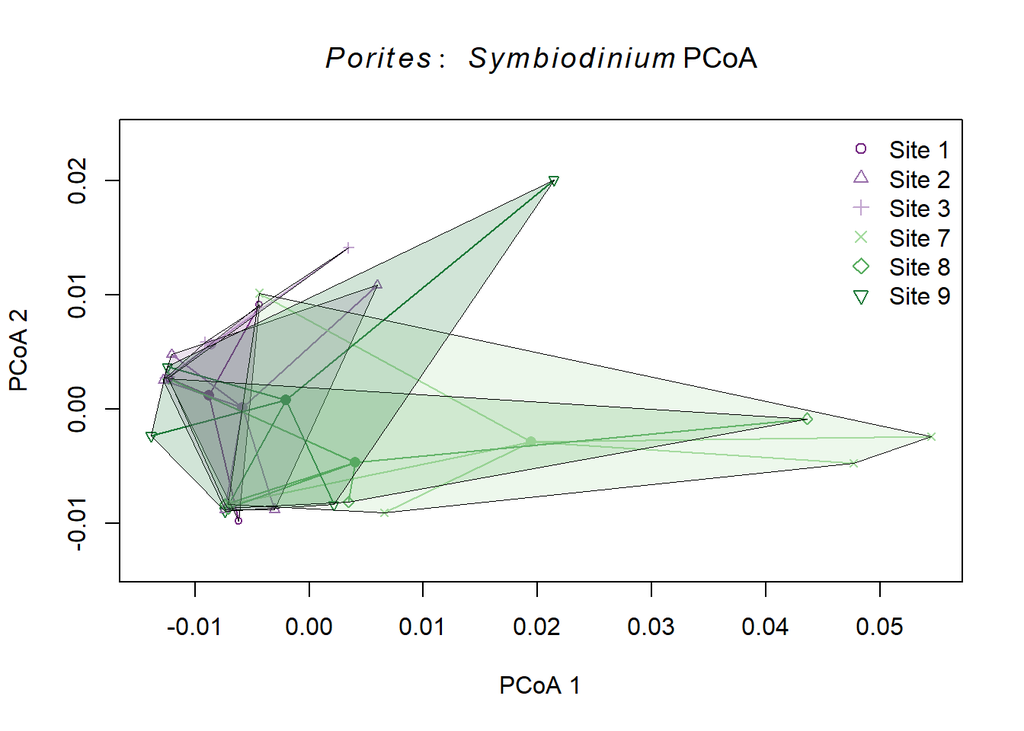

```r
## Porites
por.ufdist <- UniFrac(phy.f.t.porites, weighted=T, normalized=F, parallel=F, fast=T)
por.bd <- betadisper(d=por.ufdist, group=sample_data(phy.f.t.porites)$Site,
                       type="centroid", bias.adjust=FALSE)
plot(por.bd, hull=F, label=F, col=sitecolors, seg.col=sitecolors,
     main=expression(italic(Porites:~~Symbiodinium)~"PCoA"),
     xlab="PCoA 1", ylab="PCoA 2", sub="")
ordihull(por.bd, sample_data(phy.f.t.porites)$Site,  draw = c("polygon"),
         col = sitecolors, alpha=0.2, lwd=0.05)
legend("topright", bty="n", pch=1:6,
       legend=levels(sample_data(phy.f.t.porites)$Site),
       col=sitecolors)
```

## Test for differences in community composition among sites

### (i.e., differences in multivariate *location*)

```r
perms <- function(phy, group, trt) {
  groups <- data.frame(sample_data(phy))[, group]
  # Create data frame to populate with results
  resdf <- data.frame(
    matrix(ncol=7, nrow=nlevels(groups),
           dimnames=list(levels(data.frame(sample_data(phy))[, group]),
                         c(group, "n", "overall", "within", "between", "R2", "p")))
  )
  # Compute within- and between-treatment statistics for each group
  for (i in 1:nlevels(groups)) {
    group.name <<- levels(groups)[i]
    resdf[i, group] <- group.name
    # make subsetted phyloseq object for individual group
    phy.group <- phy
    samdat <- data.frame(sample_data(phy))
    sample_data(phy.group) <- sample_data(samdat[samdat[[group]]==group.name, ])
    samdat <- as(sample_data(phy.group), "data.frame") # sample data for subsetted phyloseq object
    # calculate distances
    ufdist <- phyloseq::distance(phy.group, "wunifrac")
    resdf$n[i] <- nsamples(phy.group)
    md <- meandist(ufdist, samdat[, trt])
    resdf$within[i] <- summary(md)$W  # Weighted mean dissimilarity within treatments
    resdf$between[i] <- summary(md)$B  # Mean dissimilarity between treatments
    resdf$overall[i] <- summary(md)$D  # Overall dissimilarity
    if (nlevels(as(sample_data(phy.group), "data.frame")[, trt]) > 1) {
      permanova <- adonis(ufdist ~ get(trt), data=samdat, permutations=99999)
      resdf$R2[i] <- permanova$aov.tab$"R2"[1]  # PERMANOVA partial R-squared
      resdf$p[i] <- permanova$aov.tab$"Pr(>F)"[1]  # PERMANOVA p-value
      #bd <- betadisper(ufdist, group=samdat[, trt])
      #resdf$bd[i] <- TukeyHSD(bd)$group[4]
    } else {
      resdf$R2[i] <- NA
      resdf$p[i] <- NA
      #resdf$bd[i] <- NA
    }
  }
  return(resdf)
}

perm.out <- perms(phy=phy.f.t, group="Species", trt="Site")
perm.out
```

```
##           Species  n   overall    within   between        R2       p
## Acropora Acropora 26 0.5193570 0.3906389 0.5395122 0.4103000 0.02192
## Porties   Porties 29 0.1228292 0.1184129 0.1235358 0.2706423 0.10679
```

## Test for differences in community variability among sites

### (i.e., differences in multivariate *dispersion*, or beta diversity)

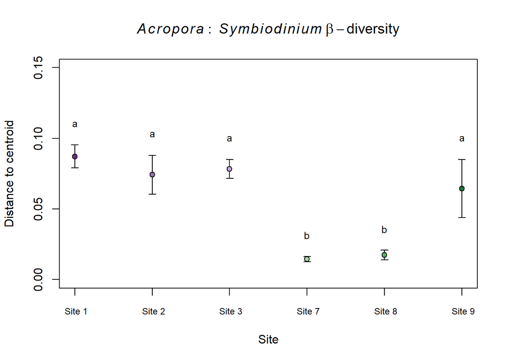

```r
acr.bd.anova <- anova(acr.bd)
acr.bdsumm <- aggregate(data.frame(mean=as.vector(acr.bd$distances)),
                        by=list(group=acr.bd$group), FUN=mean)
acr.bdsumm$se <- aggregate(as.vector(acr.bd$distances), by=list(group=acr.bd$group),
                           FUN=function(x) sd(x)/sqrt(length(x)))$x
# Use permutations to perform pairwise comparisons of group mean dispersions
acr.pt <- permutest(acr.bd, pairwise=T)
acr.bdsumm$l <- multcompLetters(acr.pt$pairwise$permuted)$Letters

with(acr.bdsumm, {
  plot(mean, type="n", ylim=c(0, 0.15), ylab="Distance to centroid", xaxt="n",
       xlab="Site", main=expression(italic(Acropora:~Symbiodinium)~beta-diversity))
  arrows(1:6, mean - se, 1:6, mean + se, length=0.05, angle=90, code=3)
  points(1:6, mean, cex=1, pch=21, bg=sitecolors)
  axis(side=1, at=1:6, cex.axis=0.75, labels=group)
  text(1:6, mean+se+0.015, l, cex=0.8)
})
```

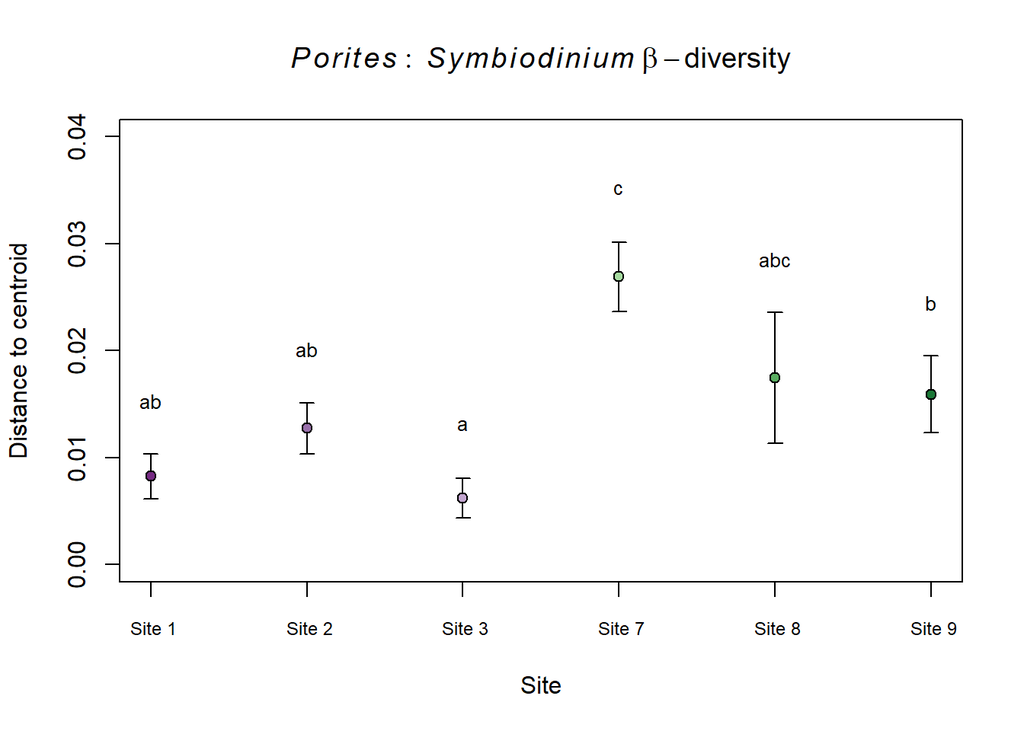

```r
## Porites
por.bd.anova <- anova(por.bd)
por.bdsumm <- aggregate(data.frame(mean=as.vector(por.bd$distances)),
                        by=list(group=por.bd$group), FUN=mean)
por.bdsumm$se <- aggregate(as.vector(por.bd$distances), by=list(group=por.bd$group),
                           FUN=function(x) sd(x)/sqrt(length(x)))$x
# Use permutations to perform pairwise comparisons of group mean dispersions
por.pt <- permutest(por.bd, pairwise=T)
por.bdsumm$l <- multcompLetters(por.pt$pairwise$permuted)$Letters

with(por.bdsumm, {
  plot(mean, type="n", ylim=c(0, 0.04), ylab="Distance to centroid", xaxt="n",
       xlab="Site", main=expression(italic(Porites:~Symbiodinium)~beta-diversity))
  arrows(1:6, mean - se, 1:6, mean + se, length=0.05, angle=90, code=3)
  points(1:6, mean, cex=1, pch=21, bg=sitecolors)
  axis(side=1, at=1:6, cex.axis=0.75, labels=group)
  text(1:6, mean+se+0.005, l, cex=0.8)
})
```

# Figure 3

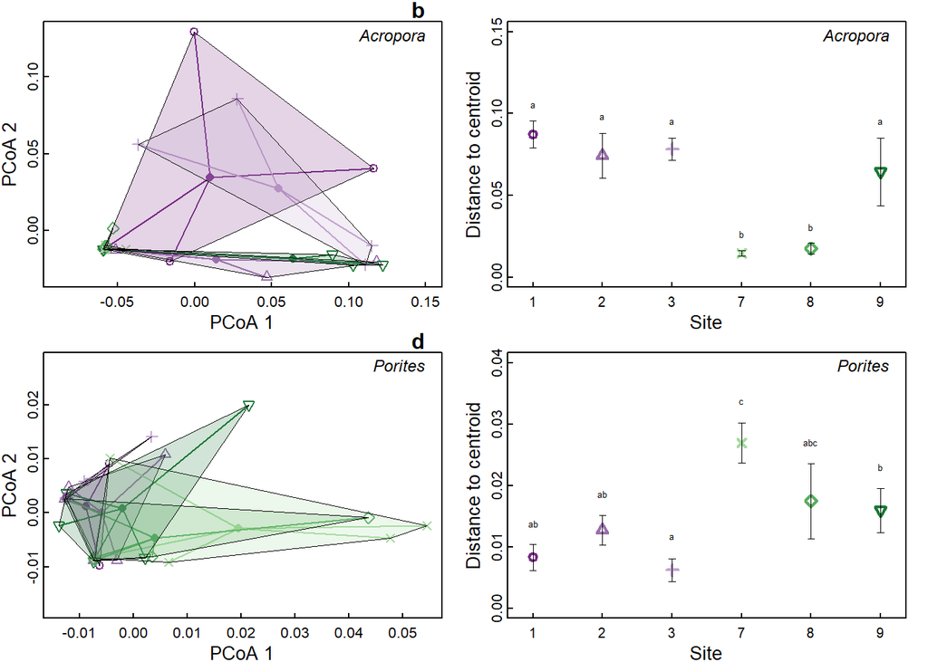

```r
par(mfrow=c(2,2), mar=c(2,2,1,1), mgp=c(1.1,0.1,0), tcl=0.2,
    cex.axis=0.8, cex.lab=1)

# Panel A
plot(acr.bd, hull=F, label=F, col=sitecolors, seg.col=sitecolors,
     xlab="PCoA 1", ylab="PCoA 2", main="", cex=1)
ordihull(acr.bd, sample_data(phy.f.t.acropora)$Site,  draw = c("polygon"),
         col = sitecolors, alpha=0.2, lwd=0.05)
# legend("topright", bty="n", pch=1:6, cex=0.6,
#        legend=levels(sample_data(phy.f.t.acropora)$Site),
#        col=sitecolors)
#text(par("usr")[1], par("usr")[4], "A.", font=2, xpd=NA, pos=2, cex=1.25)
mtext(side=3, adj=-0.23, "a", font=2)
mtext(side=3, adj=0.95, padj=1.7, substitute(paste(italic("Acropora"))), font=2, cex=0.75)

# Panel B
with(acr.bdsumm, {
  plot(mean, type="n", ylim=c(0, 0.15), ylab="Distance to centroid", xaxt="n",
       xlab="Site",xlim=c(0.85,6.15))
  points(1:6, mean, cex=1, pch=1:6, col=sitecolors, lwd=2)
  arrows(1:6, mean - se, 1:6, mean + se, length=0.025, angle=90, code=3, lwd=0.5)
  axis(side=1, at=1:6, cex.axis=0.75, labels=c(1,2,3,7,8,9))
  text(1:6, mean+se+0.01, l, cex=0.5)
})
#text(par("usr")[1]-0.3, par("usr")[4], "B.", font=2, xpd=NA, pos=2, cex=1.25)
mtext(side=3, adj=-0.25, "b", font=2)
mtext(side=3, adj=0.95, padj=1.7, substitute(paste(italic("Acropora"))), font=2, cex=0.75)

# Panel C
plot(por.bd, hull=F, label=F, col=sitecolors, seg.col=sitecolors,
     xlab="PCoA 1", ylab="PCoA 2", main="", cex=1)
ordihull(por.bd, sample_data(phy.f.t.porites)$Site,  draw = c("polygon"),
         col = sitecolors, alpha=0.2, lwd=0.05)
# legend("topright", bty="n", pch=1:6, cex=0.6,
#        legend=levels(sample_data(phy.f.t.porites)$Site),
#        col=sitecolors)
#text(par("usr")[1], par("usr")[4], "C.", font=2, xpd=NA, pos=2, cex=1.25)
mtext(side=3, adj=-0.23, "c", font=2)
mtext(side=3, adj=0.95, padj=1.85, substitute(paste(italic("Porites"))), font=2, cex=0.75)

# Panel D
with(por.bdsumm, {
  plot(mean, type="n", ylim=c(0, 0.04), ylab="Distance to centroid", xaxt="n",
       xlab="Site",xlim=c(0.85,6.15))
  points(1:6, mean, cex=1, pch=1:6, col=sitecolors, lwd=2)
  arrows(1:6, mean - se, 1:6, mean + se, length=0.025, angle=90, code=3, lwd=0.5)
  axis(side=1, at=1:6, cex.axis=0.75, labels=c(1,2,3,7,8,9))
  text(1:6, mean+se+0.0035, l, cex=0.5)
})
#text(par("usr")[1]-0.3, par("usr")[4], "D.", font=2, xpd=NA, pos=2, cex=1.25)
mtext(side=3, adj=-0.25, "d", font=2)
mtext(side=3, adj=0.95, padj=1.85, substitute(paste(italic("Porites"))), font=2, cex=0.75)
```

```r
# save as tiff
tiff("Output/Fig3.tiff", width=4, height=4, units="in", res=300)
par(mfrow=c(2,2), mar=c(2,2,1,1), mgp=c(1.1,0.1,0), tcl=0.2,
    cex.axis=0.8, cex.lab=1)

# Panel A
plot(acr.bd, hull=F, label=F, col=sitecolors, seg.col=sitecolors,
     xlab="PCoA 1", ylab="PCoA 2", main="", cex=1)
ordihull(acr.bd, sample_data(phy.f.t.acropora)$Site,  draw = c("polygon"),
         col = sitecolors, alpha=0.2, lwd=0.05)
# legend("topright", bty="n", pch=1:6, cex=0.6,
#        legend=levels(sample_data(phy.f.t.acropora)$Site),
#        col=sitecolors)
#text(par("usr")[1], par("usr")[4], "A.", font=2, xpd=NA, pos=2, cex=1.25)
mtext(side=3, adj=-0.23, "a", font=2)
mtext(side=3, adj=0.95, padj=1.7, substitute(paste(italic("Acropora"))), font=2, cex=0.75)

# Panel B
with(acr.bdsumm, {
  plot(mean, type="n", ylim=c(0, 0.15), ylab="Distance to centroid", xaxt="n",
       xlab="Site",xlim=c(0.85,6.15))
  points(1:6, mean, cex=1, pch=1:6, col=sitecolors, lwd=2)
  arrows(1:6, mean - se, 1:6, mean + se, length=0.025, angle=90, code=3, lwd=0.5)
  axis(side=1, at=1:6, cex.axis=0.75, labels=c(1,2,3,7,8,9))
  text(1:6, mean+se+0.01, l, cex=0.5)
})
#text(par("usr")[1]-0.3, par("usr")[4], "B.", font=2, xpd=NA, pos=2, cex=1.25)
mtext(side=3, adj=-0.25, "b", font=2)
mtext(side=3, adj=0.95, padj=1.7, substitute(paste(italic("Acropora"))), font=2, cex=0.75)

# Panel C
plot(por.bd, hull=F, label=F, col=sitecolors, seg.col=sitecolors,
     xlab="PCoA 1", ylab="PCoA 2", main="", cex=1)
ordihull(por.bd, sample_data(phy.f.t.porites)$Site,  draw = c("polygon"),
         col = sitecolors, alpha=0.2, lwd=0.05)
# legend("topright", bty="n", pch=1:6, cex=0.6,
#        legend=levels(sample_data(phy.f.t.porites)$Site),
#        col=sitecolors)
#text(par("usr")[1], par("usr")[4], "C.", font=2, xpd=NA, pos=2, cex=1.25)
mtext(side=3, adj=-0.23, "c", font=2)
mtext(side=3, adj=0.95, padj=1.85, substitute(paste(italic("Porites"))), font=2, cex=0.75)

# Panel D
with(por.bdsumm, {
  plot(mean, type="n", ylim=c(0, 0.04), ylab="Distance to centroid", xaxt="n",
       xlab="Site",xlim=c(0.85,6.15))
  points(1:6, mean, cex=1, pch=1:6, col=sitecolors, lwd=2)
  arrows(1:6, mean - se, 1:6, mean + se, length=0.025, angle=90, code=3, lwd=0.5)
  axis(side=1, at=1:6, cex.axis=0.75, labels=c(1,2,3,7,8,9))
  text(1:6, mean+se+0.0035, l, cex=0.5)
})
#text(par("usr")[1]-0.3, par("usr")[4], "D.", font=2, xpd=NA, pos=2, cex=1.25)
mtext(side=3, adj=-0.25, "d", font=2)
mtext(side=3, adj=0.95, padj=1.85, substitute(paste(italic("Porites"))), font=2, cex=0.75)

dev.off()
```

## What temperature metrics (models) carry the most weight in describing beta diversity?

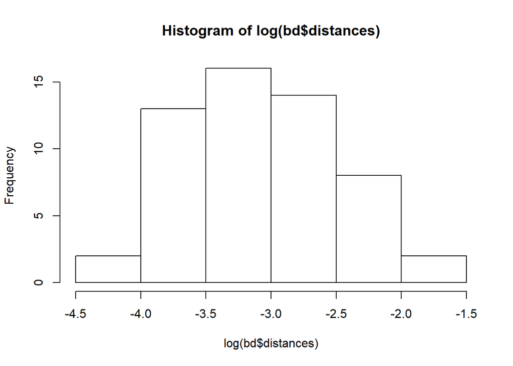

```r
ufdist <- UniFrac(phy.f.t, weighted=T, normalized=F, parallel=F, fast=T)
bd <- betadisper(d=ufdist, group=sample_data(phy.f.t)$Site,
                       type="centroid", bias.adjust=FALSE)

temp.var <- as.data.frame(sample_data(phy.f.t)[, "var"])
temp.mean <- as.data.frame(sample_data(phy.f.t)[, "mean"])
#temp.dip <- as.data.frame(sample_data(phy.f.t)[, "dip"])
temp.do30 <- as.data.frame(sample_data(phy.f.t)[, "daysover30"])
temp.du27 <- as.data.frame(sample_data(phy.f.t)[, "daysunder27"])
temp.dmmax <- as.data.frame(sample_data(phy.f.t)[, "daily.mean.max"])
temp.dmmin <- as.data.frame(sample_data(phy.f.t)[, "daily.mean.min"])
temp.dmrange <- as.data.frame(sample_data(phy.f.t)[, "daily.mean.range"])
species <- sample_data(phy.f.t)$Species
site <- sample_data(phy.f.t)$Site

hist(log(bd$distances))
```

```r
mod.var <- lmer(log(bd$distances) ~ temp.var$var*species + 1|site)
mod.mean <- lmer(log(bd$distances) ~ temp.mean$mean*species + 1|site)
#mod.dip <- lmer(log(bd$distances) ~ temp.dip$dip*species + 1|site)
mod.do30 <- lmer(log(bd$distances) ~ temp.do30$daysover30*species + 1|site)
mod.du27 <- lmer(log(bd$distances) ~ temp.du27$daysunder27*species + 1|site)
mod.dmmax <- lmer(log(bd$distances) ~ temp.dmmax$daily.mean.max*species + 1|site)
mod.dmmin <- lmer(log(bd$distances) ~ temp.dmmin$daily.mean.min*species + 1|site)
mod.dmrange <- lmer(log(bd$distances) ~ temp.dmrange$daily.mean.range*species + 1|site)

mod.test <- AICc(mod.do30, mod.du27,mod.var, mod.dmrange, mod.mean,  k = 2, REML = T)
mod.test$deltas <- round(mod.test$AICc-min(mod.test$AICc), 2)
mod.test$weights <- Weights(mod.test$AICc)
mod.test
```

```
##             df     AICc deltas    weights
## mod.do30    12 83.23791   0.64 0.24464119
## mod.du27    12 82.60066   0.00 0.33643970
## mod.var     12 84.01016   1.41 0.16627902
## mod.dmrange 12 83.85909   1.26 0.17932531
## mod.mean    12 85.64797   3.05 0.07331478
```

```r
#essentially all models are equally likely... calls for use of PC1-PC4?
```

## Does beta diversity correspond to temperature regime?

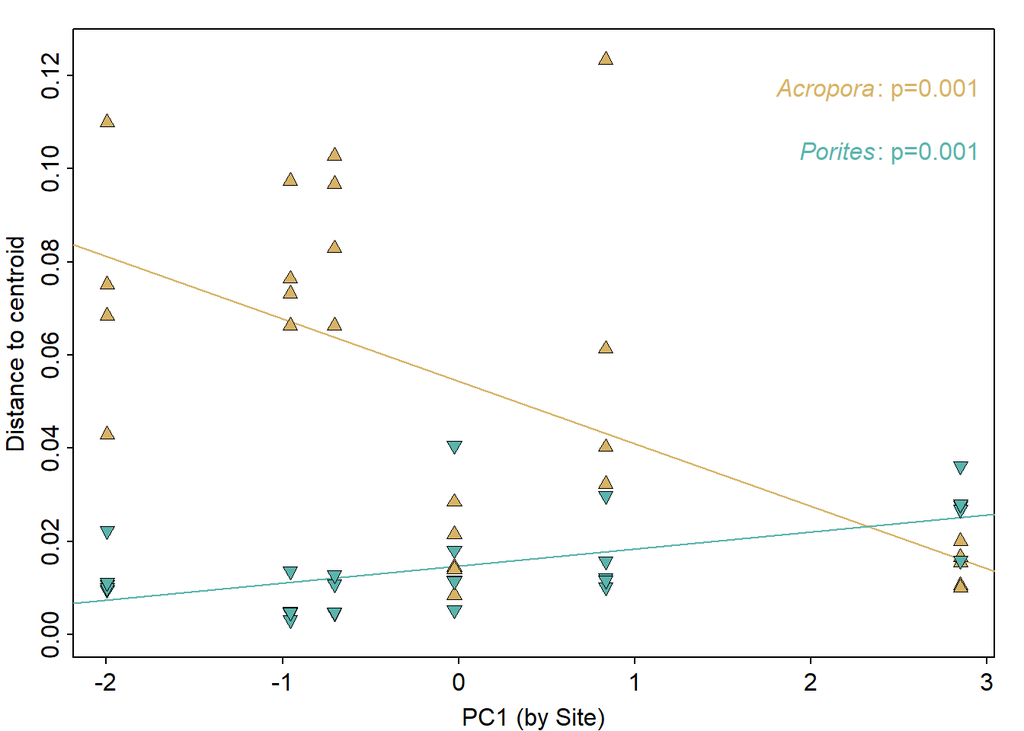

```r
plot.bd.temp <- function(metric) {
  acrdat <- data.frame(sample_data(phy.f.t.acropora))[, metric]
  pordat <- data.frame(sample_data(phy.f.t.porites))[, metric]
  plot(NA, xlim=range(acrdat), ylim=c(0,0.125),
       xlab=paste(metric, "(by Site)"), ylab="Distance to centroid")
  acr.mod <- lm(acr.bd$distances ~ acrdat)
  acr.pval <- round(anova(acr.mod)$`Pr(>F)`[1], 3)
  por.mod <- lm(por.bd$distances ~ pordat)
  por.pval <- round(anova(por.mod)$`Pr(>F)`[1], 3)
  if (acr.pval < 0.05) {  # If slope is significantly different from 0
    abline(acr.mod, col="#d8b365")
    text(x=par("usr")[2], y=quantile(par("usr")[3:4], 0.9), pos=2,
         labels=substitute(paste(italic("Acropora"), ": p=", acr.pval)),
         col="#d8b365")
  }
  if (por.pval < 0.05) {  # If slope is significantly different from 0
    abline(por.mod, col="#5ab4ac")
    text(x=par("usr")[2], y=quantile(par("usr")[3:4], 0.8), pos=2,
         labels=substitute(paste(italic("Porites"), ": p=", por.pval)),
         col="#5ab4ac")
  }
  points(acr.bd$distances ~ acrdat, pch=24, bg="#d8b365", lwd=0.5)
  points(por.bd$distances ~ pordat, pch=25, bg="#5ab4ac", lwd=0.5)
}

# Plot beta diversity as a function of temperature PCs
par(mfrow=c(1,1), mar=c(2.5,2.5,1,1), mgp=c(1.5,0.3,0), tcl=-0.2, xpd=F)
plot.bd.temp("PC1")
```

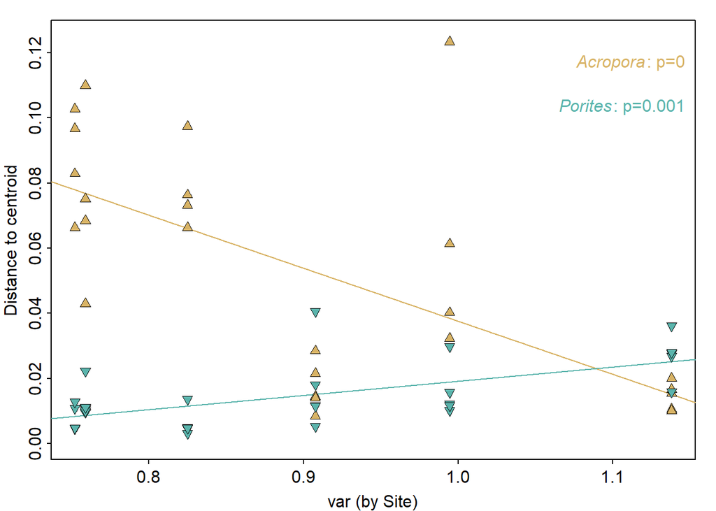

```r
#plot.bd.temp("PC2")



# # Plot beta diversity as a function of original temperature metrics
# par(mfrow=c(2,2), mar=c(2.5,2.5,1,1), mgp=c(1.5,0.3,0), tcl=-0.2)
plot.bd.temp("var")
```

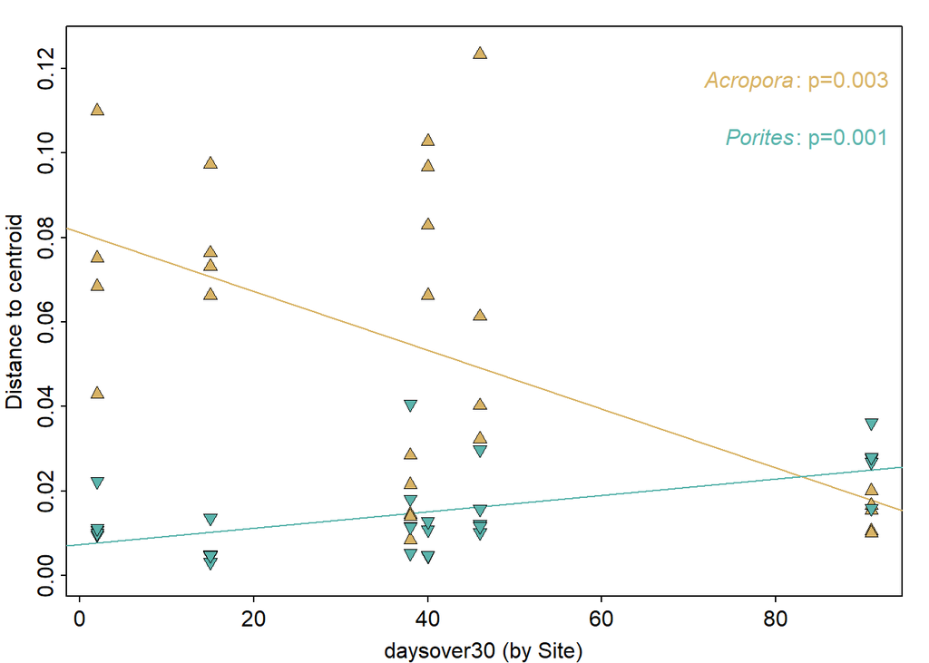

```r
#plot.bd.temp("mean")
#plot.bd.temp("dip")
plot.bd.temp("daysover30")
```

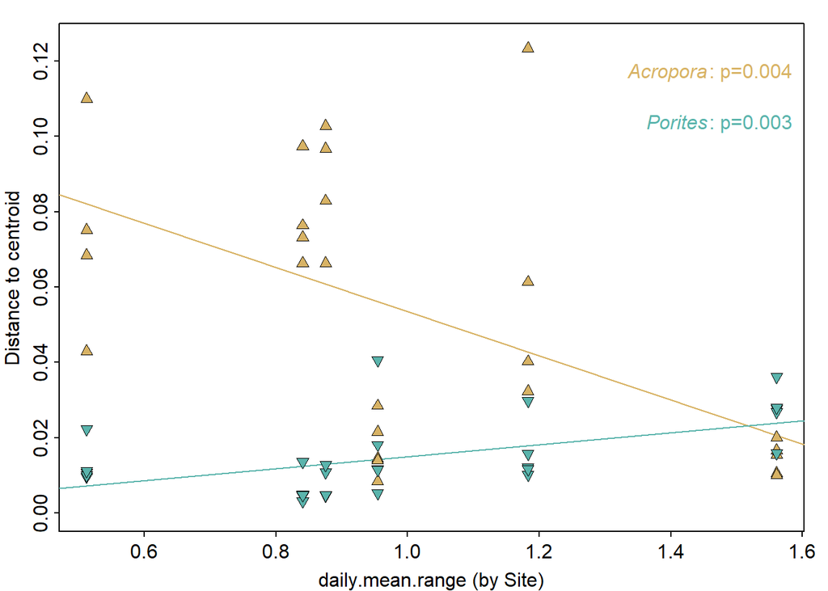

```r
#plot.bd.temp("daysunder27")
plot.bd.temp("daily.mean.range")
```

```r
# plot.bd.temp("daily.mean.min")
```

# Figure 4

```r
tiff("Output/Fig4.tiff", width=2, height=2, units="in", res=300)
par(mfrow=c(1,1), mar=c(2,2,1,1), mgp=c(1.1,0.1,0), tcl=0.2,
    cex=0.6, cex.axis=0.8)
plot.bd.temp("PC1")
mtext(side=3, adj=-0.16, "a", font=2, line=-0.3)
#plot.bd.temp("PC2")
#mtext(side=3, adj=-0.16, "b", font=2, line=-0.3)
dev.off()
```

## Constrained ordination – abbreviated version

Use the three highly correlated temperature metrics that are part of PC1 used in previous analyses, and ask how much of the variability in symbiont community composition can be explained by these three metrics. Do not attempt to disentangle them and just treat them together, as they are treated in PC1.

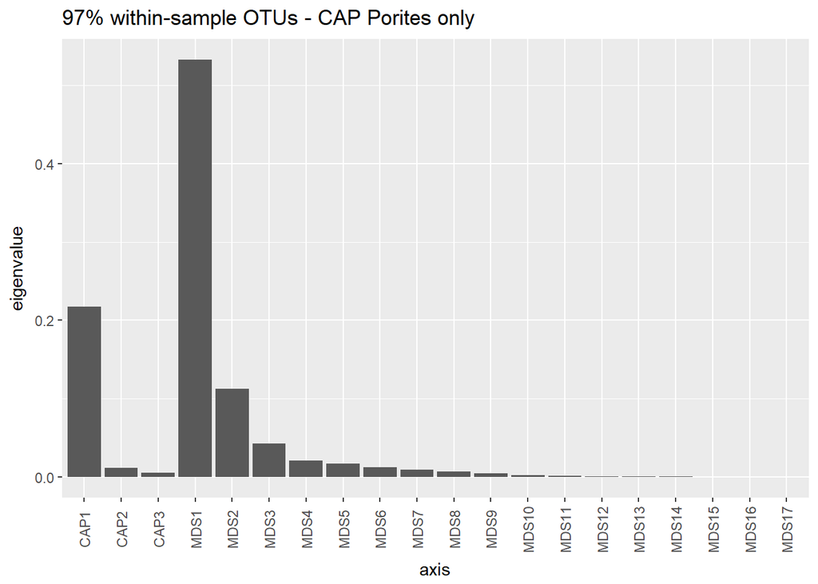

```r
# Porites
ord.porites.CAP2 <- ordinate(phy.f.t.porites,method="CAP",distance="wunifrac",formula= ~ daily.mean.range+daysover30+var)
plot_ordination(phy.f.t.porites, ord.porites.CAP2,  shape="Site",type="scree",
                title="97% within-sample OTUs - CAP Porites only")
```

```r
anova(ord.porites.CAP2)
```

```
## Permutation test for capscale under reduced model
## Permutation: free
## Number of permutations: 999
##
## Model: capscale(formula = distance ~ daily.mean.range + daysover30 + var, data = data)
##          Df SumOfSqs      F Pr(>F)
## Model     3 0.081346 2.7084  0.043 *
## Residual 25 0.250287
## ---
## Signif. codes:  0 '***' 0.001 '**' 0.01 '*' 0.05 '.' 0.1 ' ' 1
```

```r
summary(ord.porites.CAP2)$cont$importance[3,3]
```

```
## [1] 0.23428
```

```r
vif.cca(ord.porites.CAP2)
```

```
## daily.mean.range       daysover30              var
##         31.29764         15.48642         10.06642
```

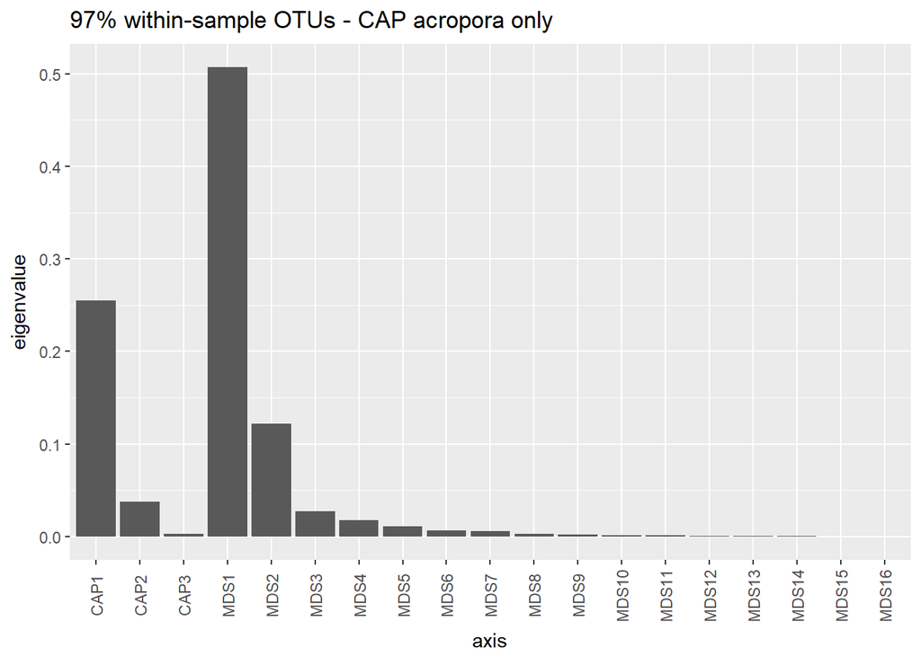

```r
# Acropora
ord.acropora.CAP2 <- ordinate(phy.f.t.acropora,method="CAP",distance="wunifrac",formula= ~ var+daily.mean.range+daysover30)
plot_ordination(phy.f.t.acropora, ord.acropora.CAP2,  shape="Site",type="scree",
                title="97% within-sample OTUs - CAP acropora only")
```

```r
anova(ord.acropora.CAP2)
```

```
## Permutation test for capscale under reduced model
## Permutation: free
## Number of permutations: 999
##
## Model: capscale(formula = distance ~ var + daily.mean.range + daysover30, data = data)
##          Df SumOfSqs      F Pr(>F)
## Model     3   1.4250 3.1769  0.016 *
## Residual 22   3.2895
## ---
## Signif. codes:  0 '***' 0.001 '**' 0.01 '*' 0.05 '.' 0.1 ' ' 1
```

```r
summary(ord.acropora.CAP2)$cont$importance[3,3]
```

```
## [1] 0.29525
```

```r
vif.cca(ord.acropora.CAP2)
```

```
##              var daily.mean.range       daysover30
##         10.26923         34.31150         16.83850
```